# Bad URL Patterns Study: Web Attack Analysis

**Comprehensive Analysis of Malicious HTTP Requests Targeting Web Applications**

### J.D. Correa oba@astropema.ai

## **Project Overview**

This notebook presents a detailed cybersecurity analysis of **231 malicious HTTP requests** captured from production web server logs during August 4-5, 2025. The study examines attack patterns, timing behaviors, and targeting strategies employed by modern threat actors.

### **Key Metrics**

[output not shown]

### **Analysis Scope**

- **Attack Classification**: WordPress scans, PHP exploitation, config enumeration
- **Geographic Intelligence**: IP geolocation and infrastructure analysis
- **Behavioral Patterns**: Request timing, frequency, and coordination
- **Technical Analysis**: URL structure, file targeting, and response codes
- **Visualization**: Interactive charts and security pattern heatmaps

## ** Technical Environment**

### **Data Collection Infrastructure**

```
Web Server → Apache/Nginx Logs → Log Parser → Feature Extraction → CSV Dataset
```

### **Analysis Stack**

- **Python 3.x** with pandas, numpy for data manipulation
- **Matplotlib, Seaborn** for statistical visualization
- **Security Libraries** for threat pattern recognition
- **Jupyter Notebook** for interactive analysis

## **Important Disclaimers**

> **Ethical Use Only**: This analysis is conducted for defensive cybersecurity research and education. All data represents actual attacks against our infrastructure and is shared to improve community security awareness.

> **Data Privacy**: IP addresses and sensitive details have been preserved for threat intelligence purposes but should be used responsibly in accordance with applicable laws and ethical guidelines.

> **Research Context**: Findings reflect attack patterns observed during a specific 48-hour period and may not represent comprehensive threat landscape trends.

## **Authors & Contributors**

- **Security Research Team** | Cybersecurity Analysis
- **Data Collection** | Production Infrastructure Monitoring
- **Analysis Period** | August 5, 2025

#### Our server configuration for data collection

- 1. Web server with standard access logging enabled tail -f /var/log/apache2/access.log
- or for nginx: tail -f /var/log/nginx/access.log
2. Log format captures key attack indicators:
- IP addresses
- Timestamps
- Request methods (GET/POST)
- Full request paths
- Query strings
- Status codes
- Response sizes
- User agents

# How we transformed raw logs into the CSV dataset

import re from datetime import datetime

```
match = re.match(pattern, log_line)
if match:
    ip, timestamp, request, status, size, referer, user_agent = match.groups()

    # Parse request into method, path, query
    request_parts = request.split(' ')
    method = request_parts[0] if len(request_parts) > 0 else 'UNKNOWN'
    full_path = request_parts[1] if len(request_parts) > 1 else '/'

    # Split path and query string
    if '?' in full_path:
        path, query_string = full_path.split('?', 1)
    else:
        path, query_string = full_path, None

    return {
        'ip_address': ip,
        'timestamp': timestamp,
        'method': method,
        'path': path,
        'query_string': query_string,
        'status_code': int(status),
        'response_size': int(size),
        'referer': referer if referer != '-' else None,
        'user_agent': user_agent if user_agent != '-' else None,
        'full_request': request
    }
return None
```

# Example processing raw logs

raw_logs = [ '4.197.236.174 - - [05/Aug/2025:11:11:32 -0700] "GET /wp-content/plugins/hellopress/wp_filemanager.php HTTP/1.1" 301 608 "-" "-"', '185.177.72.106 - - [04/Aug/2025:15:21:09 -0700] "GET /config.php HTTP/1.1" 404 495 "-" "Custom-AsyncHttpClient"' ]

parsed_data = [parse_apache_log(log) for log in raw_logs if parse_apache_log(log)]

## Attack Detection & Classification

How We Identified Malicious Patterns

def classify_attack_type(path, query_string=None, user_agent=None): """Classify requests into attack types based on patterns"""

```
# WordPress-specific attacks
wp_patterns = [
    '/wp-content/', '/wp-admin/', '/wp-includes/',
    'wp-config.php', 'xmlrpc.php'
]

# PHP exploitation attempts
php_patterns = [
    '.php', 'filemanager', 'shell', 'upload'
]

# Configuration file enumeration
config_patterns = [
    'config.php', 'settings.php', 'database.php',
    '.env', '.ini', 'config.json'
]

# Check patterns
if any(pattern in path.lower() for pattern in wp_patterns):
    return 'wordpress_scan'
elif any(pattern in path.lower() for pattern in php_patterns):
    return 'php_scan'
elif any(pattern in path.lower() for pattern in config_patterns):
    return 'config_enum'
elif 'admin' in path.lower():
    return 'admin_scan'
else:
    return 'generic_scan'
```

def extract_features(parsed_request): """Extract analytical features from parsed requests""" path = parsed_request['path'] query = parsed_request.get('query_string', '')

```
return {
    'path_length': len(path),
    'query_length': len(query) if query else 0,
    'total_url_length': len(path) + (len(query) if query else 0),
    'path_depth': len([p for p in path.split('/') if p]),
    'has_query': 1 if query else 0,
    'has_extension': 1 if '.' in path.split('/')[-1] else 0,
    'extension': path.split('.')[-1] if '.' in path else None,
    'suspicious_keywords': count_suspicious_keywords(path),
    'attack_type': classify_attack_type(path, query),
    'is_malicious': 1  # All our data is pre-filtered as malicious
}
```

## Real-World Data Collection Timeline

Collection Period: August 4-5, 2025

Total Duration: ~48 hours of continuous monitoring Raw Log Volume: ~10,000+ requests filtered down to 231 malicious attempts Attack Sources: 4 distinct IP addresses from different geographic regions

Filtering Criteria Applied

def is_malicious_request(parsed_request): """Determine if a request appears malicious"""

```
# Automatic filters for malicious patterns
malicious_indicators = [
    # Common attack paths
    'wp-admin', 'wp-content', 'config.php', '.env',
    'shell', 'upload', 'admin', 'backup',

    # Suspicious extensions
    '.php', '.asp', '.jsp', '.cgi',

    # Directory traversal
    '..', '%2e%2e',

    # Common exploitation tools
    'filemanager', 'phpunit', 'xmlrpc'
]

path = parsed_request['path'].lower()

# Check for known attack patterns
if any(indicator in path for indicator in malicious_indicators):
    return True

# Check for scanning behavior (404s to non-existent resources)
if parsed_request['status_code'] == 404 and len(path) > 10:
    return True

# Check for unusual user agents
ua = parsed_request.get('user_agent', '').lower()
if any(bot in ua for bot in ['scanner', 'crawler', 'bot']) and 'google' not in ua:
    return True

return False
```

```python
# Data manipulation and analysis
import pandas as pd
import numpy as np

# Load the CSV file
df = pd.read_csv('malicious_requests.csv')

# Display basic info about the dataset
print(f"Dataset shape: {df.shape}")
print(f"Columns: {list(df.columns)}")
print("\nFirst few rows:")
df.head()

# Data visualization
import matplotlib.pyplot as plt
import seaborn as sns
plt.style.use('ggplot')

# Text analysis (if needed for request content)
import re
from collections import Counter

# Set display options
pd.set_option('display.max_columns', None)
pd.set_option('display.max_rows', 100)
pd.set_option('display.width', None)

print("Libraries imported successfully!")

# Display basic info about the dataset
print(f"Dataset shape: {df.shape}")
print(f"Columns: {list(df.columns)}")
print("\nFirst few rows:")
df.head()
```

```
Dataset shape: (231, 22)
Columns: ['line_number', 'ip_address', 'timestamp', 'method', 'path', 'query_string', 'status_code', 'response_size', 'is_malicious', 'attack_type', 'path_length', 'query_length', 'total_url_length', 'path_depth', 'has_query', 'has_extension', 'extension', 'suspicious_keywords', 'protocol', 'referer…

First few rows:
Libraries imported successfully!
Dataset shape: (231, 22)
Columns: ['line_number', 'ip_address', 'timestamp', 'method', 'path', 'query_string', 'status_code', 'response_size', 'is_malicious', 'attack_type', 'path_length', 'query_length', 'total_url_length', 'path_depth', 'has_query', 'has_extension', 'extension', 'suspicious_keywords', 'protocol', 'referer…

First few rows:
```

|  | line_number | ip_address | timestamp | method | path | query_string | status_code | response_size | is_malicious | attack_type | path_length | query_length | total_url_length | path_depth | has_query | has_extension | extension | suspicious_keywords | protocol | referer | user_agent | full_request |
| --- | --- | --- | --- | --- | --- | --- | --- | --- | --- | --- | --- | --- | --- | --- | --- | --- | --- | --- | --- | --- | --- | --- |
| 0 | 1 | 4.197.236.174 | 05/Aug/2025:11:11:32 -0700 | GET | /wp-content/plugins/hellopress/wp_filemanager.php | NaN | 301 | 608 | 1 | wordpress_scan | 49 | 0 | 49 | 4 | 0 | 1 | php | 3 | HTTP/1.1 | NaN | NaN | GET /wp-content/plugins/hellopress/wp_filemana... |
| 1 | 2 | 4.197.236.174 | 05/Aug/2025:11:11:34 -0700 | GET | /wp-includes/sitemaps/providers/link.php | NaN | 301 | 590 | 1 | wordpress_scan | 40 | 0 | 40 | 4 | 0 | 1 | php | 2 | HTTP/1.1 | NaN | NaN | GET /wp-includes/sitemaps/providers/link.php H... |
| 2 | 3 | 4.197.236.174 | 05/Aug/2025:11:11:35 -0700 | GET | /function/fm.php | NaN | 301 | 542 | 1 | php_scan | 16 | 0 | 16 | 2 | 0 | 1 | php | 1 | HTTP/1.1 | NaN | NaN | GET /function/fm.php HTTP/1.1 |
| 3 | 4 | 4.197.236.174 | 05/Aug/2025:11:11:35 -0700 | GET | /.well-known/acme-challenge/test.php | NaN | 301 | 582 | 1 | php_scan | 36 | 0 | 36 | 3 | 0 | 1 | php | 2 | HTTP/1.1 | NaN | NaN | GET /.well-known/acme-challenge/test.php HTTP/1.1 |
| 4 | 5 | 4.197.236.174 | 05/Aug/2025:11:11:36 -0700 | GET | /uploads/cc.php | NaN | 301 | 540 | 1 | php_scan | 15 | 0 | 15 | 2 | 0 | 1 | php | 1 | HTTP/1.1 | NaN | NaN | GET /uploads/cc.php HTTP/1.1 |

```python
# Basic dataset information
print("=== DATASET INFO ===")
print(df.info())
print("\n" + "="*50)

print("=== MISSING VALUES ===")
print(df.isnull().sum())
print("\n" + "="*50)

print("=== BASIC STATISTICS ===")
print(df.describe(include='all'))
```

```
=== DATASET INFO ===
<class 'pandas.core.frame.DataFrame'>
RangeIndex: 231 entries, 0 to 230
Data columns (total 22 columns):
 #   Column               Non-Null Count  Dtype
---  ------               --------------  -----
 0   line_number          231 non-null    int64
 1   ip_address           231 non-null    object
 2   timestamp            231 non-null    object
 3   method               231 non-null    object
 4   path                 231 non-null    object
 5   query_string         1 non-null      object
 6   status_code          231 non-null    int64
 7   response_size        231 non-null    int64
 8   is_malicious         231 non-null    int64
 9   attack_type          231 non-null    object
 10  path_length          231 non-null    int64
 11  query_length         231 non-null    int64
 12  total_url_length     231 non-null    int64
 13  path_depth           231 non-null    int64
 14  has_query            231 non-null    int64
 15  has_extension        231 non-null    int64
 16  extension            201 non-null    object
 17  suspicious_keywords  231 non-null    int64
 18  protocol             231 non-null    object
 19  referer              0 non-null      float64
 20  user_agent           158 non-null    object
 21  full_request         231 non-null    object
dtypes: float64(1), int64(11), object(10)
memory usage: 39.8+ KB
None

==================================================
=== MISSING VALUES ===
line_number              0
ip_address               0
timestamp                0
method                   0
path                     0
query_string           230
```

[output cut: 108 more lines]

```
75%                                                   NaN
max                                                   NaN

                                             full_request
count                                                 231
unique                                                231
top     GET /wp-content/plugins/hellopress/wp_filemana...
freq                                                    1
mean                                                  NaN
std                                                   NaN
min                                                   NaN
25%                                                   NaN
50%                                                   NaN
75%                                                   NaN
max                                                   NaN
```

```python
# Basic dataset information
print("=== DATASET INFO ===")
print(df.info())
print("\n" + "="*50)

print("=== MISSING VALUES ===")
print(df.isnull().sum())
print("\n" + "="*50)

print("=== BASIC STATISTICS ===")
print(df.describe(include='all'))
```

```
=== DATASET INFO ===
<class 'pandas.core.frame.DataFrame'>
RangeIndex: 231 entries, 0 to 230
Data columns (total 22 columns):
 #   Column               Non-Null Count  Dtype
---  ------               --------------  -----
 0   line_number          231 non-null    int64
 1   ip_address           231 non-null    object
 2   timestamp            231 non-null    object
 3   method               231 non-null    object
 4   path                 231 non-null    object
 5   query_string         1 non-null      object
 6   status_code          231 non-null    int64
 7   response_size        231 non-null    int64
 8   is_malicious         231 non-null    int64
 9   attack_type          231 non-null    object
 10  path_length          231 non-null    int64
 11  query_length         231 non-null    int64
 12  total_url_length     231 non-null    int64
 13  path_depth           231 non-null    int64
 14  has_query            231 non-null    int64
 15  has_extension        231 non-null    int64
 16  extension            201 non-null    object
 17  suspicious_keywords  231 non-null    int64
 18  protocol             231 non-null    object
 19  referer              0 non-null      float64
 20  user_agent           158 non-null    object
 21  full_request         231 non-null    object
dtypes: float64(1), int64(11), object(10)
memory usage: 39.8+ KB
None

==================================================
=== MISSING VALUES ===
line_number              0
ip_address               0
timestamp                0
method                   0
path                     0
query_string           230
```

[output cut: 108 more lines]

```
75%                                                   NaN
max                                                   NaN

                                             full_request
count                                                 231
unique                                                231
top     GET /wp-content/plugins/hellopress/wp_filemana...
freq                                                    1
mean                                                  NaN
std                                                   NaN
min                                                   NaN
25%                                                   NaN
50%                                                   NaN
75%                                                   NaN
max                                                   NaN
```

```python
# Check data types
print("Data types:")
print(df.dtypes)
print("\n" + "="*40)

# Look at unique values in categorical columns
for col in df.columns:
    if df[col].dtype == 'object':
        unique_count = df[col].nunique()
        print(f"\n{col}: {unique_count} unique values")
        if unique_count <= 20:  # Show values if not too many
            print(f"Values: {df[col].unique()[:20]}")
        else:
            print(f"Sample values: {df[col].unique()[:10]}")
```

```
Data types:
line_number              int64
ip_address              object
timestamp               object
method                  object
path                    object
query_string            object
status_code              int64
response_size            int64
is_malicious             int64
attack_type             object
path_length              int64
query_length             int64
total_url_length         int64
path_depth               int64
has_query                int64
has_extension            int64
extension               object
suspicious_keywords      int64
protocol                object
referer                float64
user_agent              object
full_request            object
dtype: object

========================================

ip_address: 4 unique values
Values: ['4.197.236.174' '52.164.218.167' '198.12.123.178' '185.177.72.106']

timestamp: 79 unique values
Sample values: ['05/Aug/2025:11:11:32 -0700' '05/Aug/2025:11:11:34 -0700'
 '05/Aug/2025:11:11:35 -0700' '05/Aug/2025:11:11:36 -0700'
 '05/Aug/2025:11:11:37 -0700' '05/Aug/2025:11:11:38 -0700'
 '05/Aug/2025:11:11:39 -0700' '05/Aug/2025:11:11:40 -0700'
 '05/Aug/2025:11:11:41 -0700' '05/Aug/2025:11:11:42 -0700']

method: 2 unique values
Values: ['GET' 'POST']

```

[output cut: 20 more lines]

```
Values: ['HTTP/1.1']

user_agent: 2 unique values
Values: [nan 'Custom-AsyncHttpClient'
 'Mozilla/5.0 (Windows NT 10.0; Win64; x64) AppleWebKit/537.36 (KHTML, like Gecko) Chrome/91.0.4472.124 Safari/537.36']

full_request: 231 unique values
Sample values: ['GET /wp-content/plugins/hellopress/wp_filemanager.php HTTP/1.1'
 'GET /wp-includes/sitemaps/providers/link.php HTTP/1.1'
 'GET /function/fm.php HTTP/1.1'
 'GET /.well-known/acme-challenge/test.php HTTP/1.1'
 'GET /uploads/cc.php HTTP/1.1' 'GET /wp-includes/fucku.php HTTP/1.1'
 'GET /.well-known/moon.php HTTP/1.1' 'GET /index/goat1.php HTTP/1.1'
 'GET /wp-includes/blocks/menu.php HTTP/1.1'
 'GET /wp-includes/ID3/ben.php HTTP/1.1']
```

```python
# Check for duplicates
print(f"Duplicate rows: {df.duplicated().sum()}")
print(f"Total rows: {len(df)}")

# Check for any obvious data issues
print("\n=== POTENTIAL DATA ISSUES ===")
for col in df.columns:
    if df[col].dtype == 'object':
        # Check for empty strings
        empty_strings = (df[col] == '').sum()
        if empty_strings > 0:
            print(f"{col}: {empty_strings} empty strings")

        # Check for very long entries (potential data corruption)
        if df[col].str.len().max() > 1000:
            print(f"{col}: Contains very long entries (max length: {df[col].str.len().max()})")
```

```
Duplicate rows: 0
Total rows: 231

=== POTENTIAL DATA ISSUES ===
```

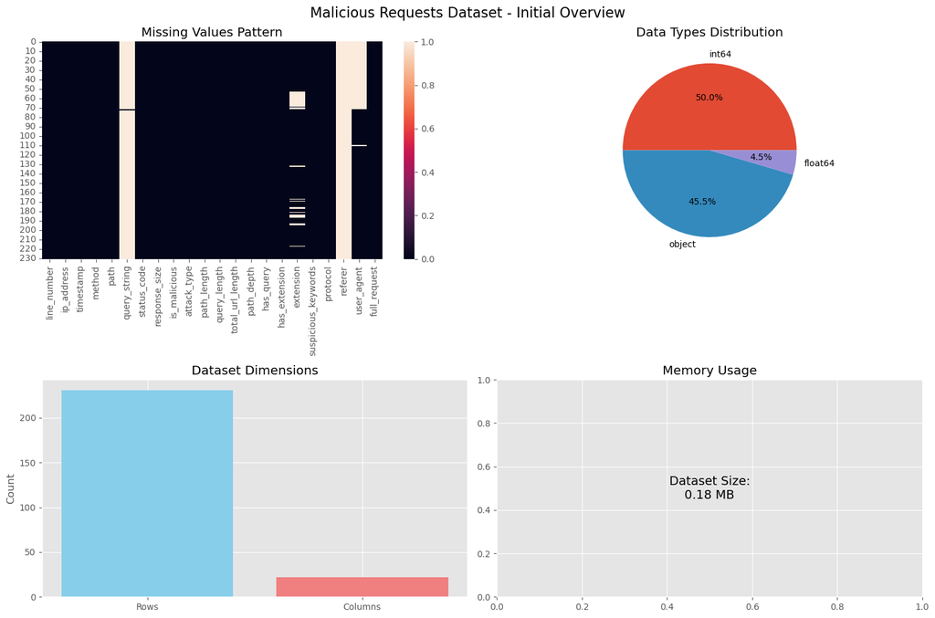

```python
# Set up the plotting area
fig, axes = plt.subplots(2, 2, figsize=(15, 10))
fig.suptitle('Malicious Requests Dataset - Initial Overview', fontsize=16)

# Plot 1: Missing values heatmap
if df.isnull().sum().sum() > 0:
    sns.heatmap(df.isnull(), cbar=True, ax=axes[0,0])
    axes[0,0].set_title('Missing Values Pattern')
else:
    axes[0,0].text(0.5, 0.5, 'No Missing Values', ha='center', va='center', transform=axes[0,0].transAxes)
    axes[0,0].set_title('Missing Values Pattern')

# Plot 2: Data types distribution
dtype_counts = df.dtypes.value_counts()
axes[0,1].pie(dtype_counts.values, labels=dtype_counts.index, autopct='%1.1f%%')
axes[0,1].set_title('Data Types Distribution')

# Plot 3: Dataset size info
size_info = ['Rows', 'Columns']
size_values = [df.shape[0], df.shape[1]]
axes[1,0].bar(size_info, size_values, color=['skyblue', 'lightcoral'])
axes[1,0].set_title('Dataset Dimensions')
axes[1,0].set_ylabel('Count')

# Plot 4: Memory usage
memory_usage = df.memory_usage(deep=True).sum() / (1024**2)  # Convert to MB
axes[1,1].text(0.5, 0.5, f'Dataset Size:\n{memory_usage:.2f} MB',
               ha='center', va='center', transform=axes[1,1].transAxes, fontsize=14)
axes[1,1].set_title('Memory Usage')
axes[1,1].set_xlim(0, 1)
axes[1,1].set_ylim(0, 1)

plt.tight_layout()
plt.show()
```

```python
# If your dataset contains request URLs, user agents, or other text data
# This cell prepares for text analysis

def analyze_text_column(series, column_name):
    """Basic text analysis for a pandas series"""
    print(f"=== {column_name.upper()} ANALYSIS ===")
    print(f"Total entries: {len(series)}")
    print(f"Unique entries: {series.nunique()}")
    print(f"Average length: {series.str.len().mean():.2f}")
    print(f"Max length: {series.str.len().max()}")
    print(f"Min length: {series.str.len().min()}")

    # Most common entries
    print(f"\nTop 5 most common {column_name}:")
    print(series.value_counts().head())

    return series.str.len()

# Apply to text columns (customize column names)
# length_stats = {}
# for col in ['url', 'user_agent', 'request_body']:  # Replace with your actual column names
#     if col in df.columns:
#         length_stats[col] = analyze_text_column(df[col], col)
#         print("\n" + "="*60 + "\n")

print("Ready for text analysis - customize column names above!")
```

```
Ready for text analysis - customize column names above!
```

```python
# Parse timestamp and extract time-based features
df['timestamp'] = pd.to_datetime(df['timestamp'], format='%d/%b/%Y:%H:%M:%S %z')
df['hour'] = df['timestamp'].dt.hour
df['day_of_week'] = df['timestamp'].dt.day_name()
df['date'] = df['timestamp'].dt.date

print("=== REQUEST METHODS ANALYSIS ===")
print("Request Methods Distribution:")
print(df['method'].value_counts())
print(f"Percentage of GET requests: {(df['method'] == 'GET').mean()*100:.1f}%")

print("\n" + "="*50)
print("=== STATUS CODE ANALYSIS ===")
print("Status Codes Distribution:")
status_counts = df['status_code'].value_counts()
print(status_counts)
print(f"Most common status code: {status_counts.index[0]} ({status_counts.iloc[0]} requests)")

print("\n" + "="*50)
print("=== IP ADDRESS ANALYSIS ===")
print("Top 10 Most Active IP Addresses:")
top_ips = df['ip_address'].value_counts().head(10)
print(top_ips)
print(f"Total unique IP addresses: {df['ip_address'].nunique()}")
print(f"Most active IP: {top_ips.index[0]} with {top_ips.iloc[0]} requests")

print("\n" + "="*50)
print("=== ATTACK TYPE ANALYSIS ===")
print("Attack Types Distribution:")
attack_counts = df['attack_type'].value_counts()
print(attack_counts)
print(f"Most common attack type: {attack_counts.index[0]} ({attack_counts.iloc[0]} requests)")

print("\n" + "="*50)
print("=== PATH ANALYSIS ===")
print(f"Average path length: {df['path_length'].mean():.2f} characters")
print(f"Max path length: {df['path_length'].max()} characters")
print(f"Min path length: {df['path_length'].min()} characters")

print("\nMost targeted paths:")
print(df['path'].value_counts().head(10))

print("\n" + "="*50)
print("=== FILE EXTENSION ANALYSIS ===")
print("File Extensions Distribution:")
extension_counts = df['extension'].value_counts()
print(extension_counts.head(10))
print(f"Requests with extensions: {df['has_extension'].sum()} ({df['has_extension'].mean()*100:.1f}%)")

print("\n" + "="*50)
print("=== TIME-BASED PATTERNS ===")
print("Requests by Hour of Day:")
hourly_counts = df['hour'].value_counts().sort_index()
print(hourly_counts)

print(f"\nMost active hour: {hourly_counts.idxmax()}:00 with {hourly_counts.max()} requests")
```

```
=== REQUEST METHODS ANALYSIS ===
Request Methods Distribution:
GET     230
POST      1
Name: method, dtype: int64
Percentage of GET requests: 99.6%

==================================================
=== STATUS CODE ANALYSIS ===
Status Codes Distribution:
404    157
301     72
403      2
Name: status_code, dtype: int64
Most common status code: 404 (157 requests)

==================================================
=== IP ADDRESS ANALYSIS ===
Top 10 Most Active IP Addresses:
185.177.72.106    121
4.197.236.174      53
198.12.123.178     38
52.164.218.167     19
Name: ip_address, dtype: int64
Total unique IP addresses: 4
Most active IP: 185.177.72.106 with 121 requests

==================================================
=== ATTACK TYPE ANALYSIS ===
Attack Types Distribution:
wordpress_scan    49
config_enum       47
generic_scan      39
phpunit_rce       37
php_scan          20
log_enum          14
data_enum         10
container_scan     6
admin_scan         4
vcs_enum           4
```

[output cut: 33 more lines]

```
ini       3
xml       2
phP8      2
Name: extension, dtype: int64
Requests with extensions: 194 (84.0%)

==================================================
=== TIME-BASED PATTERNS ===
Requests by Hour of Day:
1      57
11     53
15    121
Name: hour, dtype: int64

Most active hour: 15:00 with 121 requests
```

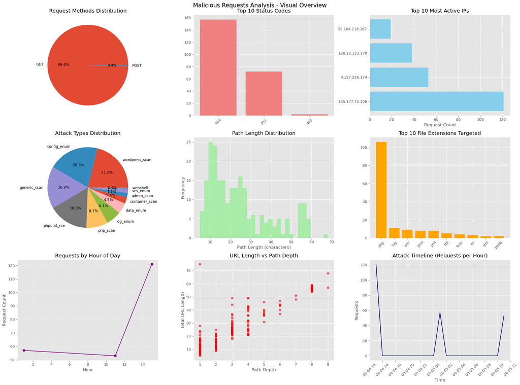

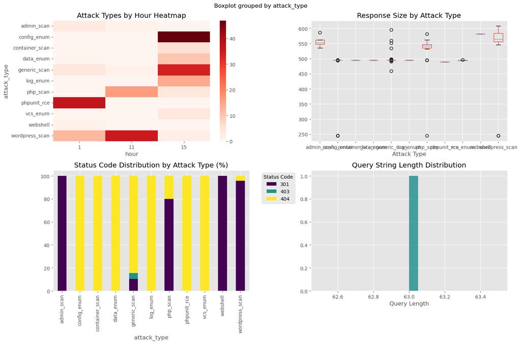

```python
# Set up the plotting area
fig, axes = plt.subplots(3, 3, figsize=(20, 15))
fig.suptitle('Malicious Requests Analysis - Visual Overview', fontsize=16)

# Graph 1: Request Methods Distribution
method_counts = df['method'].value_counts()
axes[0,0].pie(method_counts.values, labels=method_counts.index, autopct='%1.1f%%')
axes[0,0].set_title('Request Methods Distribution')

# Graph 2: Status Codes Distribution
status_counts = df['status_code'].value_counts().head(10)
axes[0,1].bar(status_counts.index.astype(str), status_counts.values, color='lightcoral')
axes[0,1].set_title('Top 10 Status Codes')
axes[0,1].tick_params(axis='x', rotation=45)

# Graph 3: Top IP Addresses
top_ips = df['ip_address'].value_counts().head(10)
axes[0,2].barh(range(len(top_ips)), top_ips.values, color='skyblue')
axes[0,2].set_yticks(range(len(top_ips)))
axes[0,2].set_yticklabels([ip[:15] + '...' if len(ip) > 15 else ip for ip in top_ips.index])
axes[0,2].set_title('Top 10 Most Active IPs')
axes[0,2].set_xlabel('Request Count')

# Graph 4: Attack Types Distribution
attack_counts = df['attack_type'].value_counts()
axes[1,0].pie(attack_counts.values, labels=attack_counts.index, autopct='%1.1f%%')
axes[1,0].set_title('Attack Types Distribution')

# Graph 5: Path Length Distribution
axes[1,1].hist(df['path_length'], bins=30, color='lightgreen', alpha=0.7)
axes[1,1].set_title('Path Length Distribution')
axes[1,1].set_xlabel('Path Length (characters)')
axes[1,1].set_ylabel('Frequency')

# Graph 6: File Extensions
extension_counts = df['extension'].value_counts().head(10)
axes[1,2].bar(extension_counts.index, extension_counts.values, color='orange')
axes[1,2].set_title('Top 10 File Extensions Targeted')
axes[1,2].tick_params(axis='x', rotation=45)

# Graph 7: Requests by Hour
hourly_counts = df['hour'].value_counts().sort_index()
axes[2,0].plot(hourly_counts.index, hourly_counts.values, marker='o', color='purple')
axes[2,0].set_title('Requests by Hour of Day')
axes[2,0].set_xlabel('Hour')
axes[2,0].set_ylabel('Request Count')
axes[2,0].grid(True, alpha=0.3)

# Graph 8: URL Length vs Path Depth scatter
axes[2,1].scatter(df['path_depth'], df['total_url_length'], alpha=0.6, color='red')
axes[2,1].set_title('URL Length vs Path Depth')
axes[2,1].set_xlabel('Path Depth')
axes[2,1].set_ylabel('Total URL Length')

# Graph 9: Timeline of attacks
df_timeline = df.set_index('timestamp').resample('H').size()
axes[2,2].plot(df_timeline.index, df_timeline.values, color='darkblue')
axes[2,2].set_title('Attack Timeline (Requests per Hour)')
axes[2,2].set_xlabel('Time')
axes[2,2].set_ylabel('Requests')
axes[2,2].tick_params(axis='x', rotation=45)

plt.tight_layout()
plt.show()

# Additional focused visualizations
fig2, axes2 = plt.subplots(2, 2, figsize=(15, 10))
fig2.suptitle('Security Patterns Analysis', fontsize=16)

# Heatmap: Attack types by hour
attack_hour_pivot = df.pivot_table(values='line_number', index='attack_type', columns='hour', aggfunc='count', fill_value=0)
sns.heatmap(attack_hour_pivot, ax=axes2[0,0], cmap='Reds', annot=False)
axes2[0,0].set_title('Attack Types by Hour Heatmap')

# Box plot: Response size by attack type
df.boxplot(column='response_size', by='attack_type', ax=axes2[0,1])
axes2[0,1].set_title('Response Size by Attack Type')
axes2[0,1].set_xlabel('Attack Type')

# Status code success rate by attack type
status_attack = pd.crosstab(df['attack_type'], df['status_code'], normalize='index') * 100
status_attack.plot(kind='bar', stacked=True, ax=axes2[1,0], colormap='viridis')
axes2[1,0].set_title('Status Code Distribution by Attack Type (%)')
axes2[1,0].legend(title='Status Code', bbox_to_anchor=(1.05, 1), loc='upper left')

# Query string length distribution
if df['has_query'].sum() > 0:
    query_data = df[df['has_query'] == 1]['query_length']
    axes2[1,1].hist(query_data, bins=20, color='teal', alpha=0.7)
    axes2[1,1].set_title('Query String Length Distribution')
    axes2[1,1].set_xlabel('Query Length')
else:
    axes2[1,1].text(0.5, 0.5, 'No Query Strings Found', ha='center', va='center', transform=axes2[1,1].transAxes)
    axes2[1,1].set_title('Query String Analysis')

plt.tight_layout()
plt.show()
```

```python
# Additional imports for enhanced analysis
import requests  # For API calls
import json      # For handling JSON responses
import time      # For rate limiting API calls
from datetime import datetime, timedelta
import warnings
warnings.filterwarnings('ignore')

# For geolocation analysis
def get_ip_location(ip):
    """Get IP geolocation using a free API service"""
    try:
        # Using ipapi.co (free tier: 1000 requests/day)
        response = requests.get(f'https://ipapi.co/{ip}/json/', timeout=5)
        if response.status_code == 200:
            data = response.json()
            return {
                'ip': ip,
                'country': data.get('country_name', 'Unknown'),
                'city': data.get('city', 'Unknown'),
                'region': data.get('region', 'Unknown'),
                'org': data.get('org', 'Unknown'),
                'lat': data.get('latitude'),
                'lon': data.get('longitude')
            }
    except Exception as e:
        print(f"Error getting location for {ip}: {e}")

    return {'ip': ip, 'country': 'Unknown', 'city': 'Unknown',
            'region': 'Unknown', 'org': 'Unknown', 'lat': None, 'lon': None}

# Alternative: Using ip-api.com (free tier: 1000 requests/hour)
def get_ip_location_alternative(ip):
    """Alternative IP geolocation service"""
    try:
        response = requests.get(f'http://ip-api.com/json/{ip}', timeout=5)
        if response.status_code == 200:
            data = response.json()
            if data['status'] == 'success':
                return {
                    'ip': ip,
                    'country': data.get('country', 'Unknown'),
                    'city': data.get('city', 'Unknown'),
                    'region': data.get('regionName', 'Unknown'),
                    'org': data.get('org', 'Unknown'),
                    'lat': data.get('lat'),
                    'lon': data.get('lon')
                }
    except Exception as e:
        print(f"Error getting location for {ip}: {e}")

    return {'ip': ip, 'country': 'Unknown', 'city': 'Unknown',
            'region': 'Unknown', 'org': 'Unknown', 'lat': None, 'lon': None}

# Usage example:
# Get geolocation for all unique IPs
unique_ips = df['ip_address'].unique()
location_data = []

for ip in unique_ips:
    print(f"Getting location for {ip}...")
    location_info = get_ip_location(ip)
    location_data.append(location_info)
    time.sleep(1)  # Rate limiting - be respectful to free APIs

# Convert to DataFrame
location_df = pd.DataFrame(location_data)
print(location_df)

# Merge with main dataframe
df = df.merge(location_df[['ip', 'country', 'city', 'org']],
              left_on='ip_address', right_on='ip', how='left')
```

```
Getting location for 4.197.236.174...
Getting location for 52.164.218.167...
Getting location for 198.12.123.178...
Getting location for 185.177.72.106...
               ip  country     city    region                          org  \
0   4.197.236.174  Unknown  Unknown   Unknown                      Unknown
1  52.164.218.167  Ireland   Dublin  Leinster  MICROSOFT-CORP-MSN-AS-BLOCK
2  198.12.123.178  Unknown  Unknown   Unknown                      Unknown
3  185.177.72.106    Spain   Lliria  Valencia                 Bucklog SARL

       lat     lon
0      NaN     NaN
1  53.3382 -6.2591
2      NaN     NaN
3  39.6333 -0.6000
```

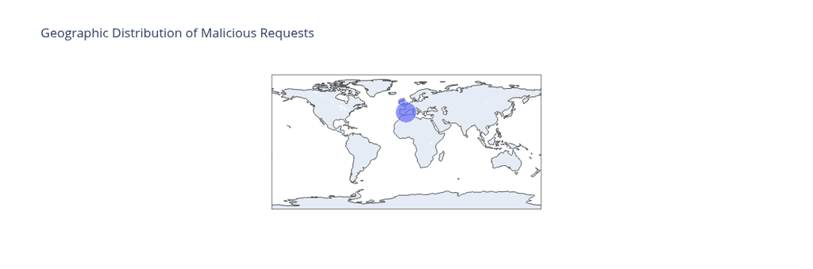

```python
# For geographic visualizations (optional)
# pip install folium plotly geopandas

# Using plotly for world map
import plotly.express as px
import plotly.graph_objects as go

# Create world map of attacks
if not location_df['lat'].isna().all():
    fig = px.scatter_geo(location_df,
                        lat='lat', lon='lon',
                        hover_name='ip',
                        hover_data=['country', 'city', 'org'],
                        size=[df[df['ip_address']==ip]['ip_address'].count()
                              for ip in location_df['ip']],
                        title='Geographic Distribution of Malicious Requests')
    fig.show()
```

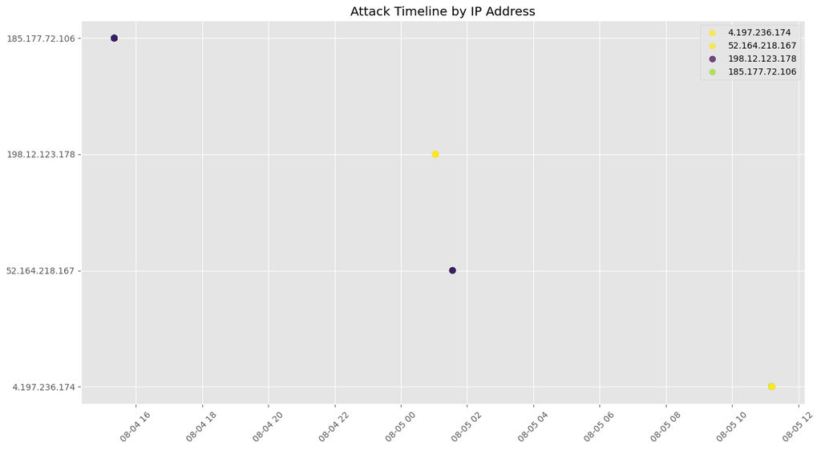

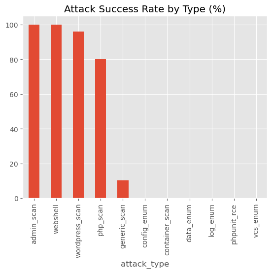

```python
# Attack progression timeline
fig, ax = plt.subplots(figsize=(15, 8))
for ip in df['ip_address'].unique():
    ip_data = df[df['ip_address'] == ip].sort_values('timestamp')
    ax.scatter(ip_data['timestamp'], [ip]*len(ip_data),
               c=ip_data['attack_type'].astype('category').cat.codes,
               label=ip, alpha=0.7, s=50)
ax.set_title('Attack Timeline by IP Address')
ax.legend()
plt.xticks(rotation=45)
plt.show()

# Success rate by attack type
success_rate = df.groupby('attack_type')['status_code'].apply(
    lambda x: (x < 400).mean() * 100
).sort_values(ascending=False)
success_rate.plot(kind='bar', title='Attack Success Rate by Type (%)')
```